# Use `mrgsolve` to replace NONMEM simulations

### Generate exporure metrics

This can be used for showing PK variability or as input for E-R predictions

```r
exposure.metrics.dose.range <-
  df.mrgsim.dose.range %>%
  filter(TIME >= max(dosetime),
         TIME <= max(dosetime) + 24) %>%
  group_by(NMID, NAMT) %>%
  summarize(AUCss = max(AUCCENT) - min(AUCCENT),
            Cmaxss = max(IPRED),
            Cminss = min(IPRED),
            .groups = "drop")

exposure.metrics.dose.range
```

```
## # A tibble: 3,000 x 5
##     NMID NAMT  AUCss Cmaxss Cminss
##    <dbl> <fct> <dbl>  <dbl>  <dbl>
##  1     1 600   2421.   219.   52.9
##  2     2 600   3903.   288.   96.9
##  3     3 600   4750.   319.  132.
##  4     4 600   3037.   211.   80.4
##  5     5 600   5466.   384.  161.
##  6     6 600   5096.   395.  151.
##  7     7 600   2923.   254.   64.9
##  8     8 600   7162.   422.  217.
##  9     9 600   7186.   443.  222.
## 10    10 600   4365.   345.  108.
## # … with 2,990 more rows
```

```r
exposure.metrics.qtile <-
  exposure.metrics.dose.range %>%
  pivot_longer(AUCss:Cminss, names_to = "metric") %>%
  group_by(NAMT, metric) %>%
  summarize(quibble(value), .groups = "drop") %>%
  pivot_wider(names_from = value_q, values_from = value)

exposure.metrics.qtile
```

```
## # A tibble: 9 x 5
##   NAMT  metric     P05    P50    P95
##   <fct> <chr>    <dbl>  <dbl>  <dbl>
## 1 600   AUCss   3077.   4779.  7551.
## 2 600   Cmaxss   241.    344.   489.
## 3 600   Cminss    72.2   133.   240.
## 4 1200  AUCss   6241.   9789. 15130.
## 5 1200  Cmaxss   506.    697.   957.
## 6 1200  Cminss   145.    277.   477.
## 7 2400  AUCss  12418.  19322. 30597.
## 8 2400  Cmaxss   961.   1376.  1956.
## 9 2400  Cminss   295.    543.   974.
```

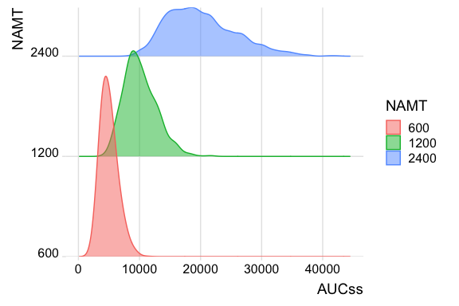

```r
exposure.metrics.dose.range %>%
  ggplot(aes(AUCss, NAMT, fill = NAMT, color = NAMT)) +
  ggridges::geom_density_ridges(alpha = 0.5) +
  scale_y_discrete(expand = c(0, 0)) +
  ggridges::theme_ridges()
```

## Different treatment intervals

You can use ii and addl statements like NONMEM

### Generate sim data

```r
set.seed(1234)

n.subj.per.dose <- 1000
df.dose.interval.setting <-
  tribble(~AMT, ~II, ~ADDL, ~NDOSE,
          600,  12,  29,    "600mg BID",
          1200, 24,  14,    "1200mg QD")
time.sim.end <- 15 * 24

n.subj.all <- n.subj.per.dose * nrow(df.dose.interval.setting)

# Generate dosing records

df.dose <-
  df.dose.interval.setting %>%
  expand_grid(IDdummy = 1:n.subj.per.dose) %>%
  select(-IDdummy) %>%
  mutate(NMID = row_number(),
         TIME = 0, CMT = 1, EVID = 1)

# Here we are resampling covariates from the observed data
df.cov <-
  df.nm %>%
  select(NMID, WT, SEX) %>%
  distinct() %>%
  slice_sample(n = n.subj.all, replace = TRUE) %>%
  mutate(NMID = row_number())


df.sim.dose.intervals <-
  full_join(df.dose, df.cov, by = "NMID") %>%
  # Add parameter values
  expand_grid(df.theta) %>%
  mutate(ID = NMID)
```

### Run

```r
mrgsim.dose.intervals <-
  mod_pk %>%
  carry_out(NMID, AMT, EVID, WT, SEX) %>%
  data_set(df.sim.dose.intervals) %>%
  omat(d.omat) %>%
  mrgsim(end = time.sim.end, delta = 1,
         recover = "NDOSE")

df.mrgsim.dose.intervals <-
  as_tibble(mrgsim.dose.intervals) %>%
  filter(EVID == 0)
```

### Plot

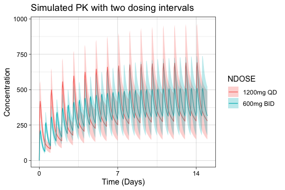

```r
df.mrgsim.dose.intervals.qtile <-
  df.mrgsim.dose.intervals %>%
  group_by(NDOSE, TIME) %>%
  summarize(quibble(IPRED),
            n = n(),
            .groups = "drop") %>%
  pivot_wider(names_from = IPRED_q, values_from = IPRED)

df.mrgsim.dose.intervals.qtile %>%
  ggplot(aes(TIME, P50, color = NDOSE)) +
  geom_line() +
  geom_ribbon(aes(ymax = P95, ymin = P05, fill = NDOSE),
              alpha = .3, color = NA) +
  xgx_scale_x_time_units(units_dataset = time_units_dataset,
                         units_plot    = time_units_plot) +
  # facet_wrap(~DFREQ, labeller = "label_both", nrow = 1) +
  labs(title = "Simulated PK with two dosing intervals",
       y = "Concentration")
```

# Calc individual PK metrics

Sometimes we want to generate PK metrics for each individual (e.g. AUC<sub>ss</sub>, C<sub>min,ss</sub>, C<sub>min,ss</sub>) with empirical Bayes estimates (EBE), using protocol-defined dosing schedules rather than actual dosing records.  
This may be preferred in some situations where we want to avoid post-randomization bias.

## Run

```r
# 15-day QD dosing of 1200mg
df.sim.prot.dose <-
  df.nm %>%
  select(NMID, WT, SEX) %>%
  distinct() %>%
  mutate(TIME = 0, AMT = 1200, II = 24, ADDL = 14, CMT = 1, EVID = 1) %>%
  # Add parameter and ETA values
  expand_grid(df.theta) %>%
  left_join(df.eta, by = "NMID") %>%
  mutate(ID = NMID)

time.sim.end <- 16 * 24


# Model run setting
mod_pk.prot.dose <-
  mod_pk %>%
  # Set Omega and Sigma to zero
  zero_re() %>%
  # Keep these variables in the output
  # a.u.g is a flag for augmented sampling timepoints
  carry_out(NMID, AMT, EVID, WT, SEX, a.u.g) %>%
  # Specify that we want to add augmented timepoints (defined with delta)
  obsaug()


# IPRED
mrgsim.ipred.prot.dose <-
  mod_pk.prot.dose %>%
  data_set(df.sim.prot.dose) %>%
  mrgsim(end = time.sim.end, delta = 1)

df.mrgsim.ipred.prot.dose <-
  as_tibble(mrgsim.ipred.prot.dose)
```

## Exporure metrics for individual subjects

This can be used for E-R analysis

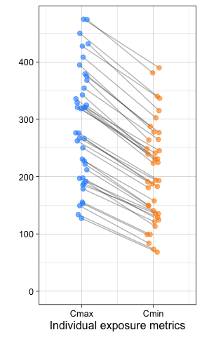

```r
# You can use PKNCA::pk.calc.auc if the mrgsolve model does not calculate AUC in ODE
# exposure.metrics.ipred.prot.dose <-
#   df.mrgsim.ipred.prot.dose %>%
#   filter(TIME >= 15 * 24) %>%
#   mutate(TAD = TIME -15 * 24) %>%
#   group_by(NMID) %>%
#   summarize(AUCss = PKNCA::pk.calc.auc(IPRED, TAD),
#             Cmaxss = max(IPRED),
#             Cminss = min(IPRED),
#             .groups = "drop")

# If mrgsolve calculate cumulative AUC, then max(AUC) - min(AUC)
# is AUC for the time interval
exposure.metrics.ipred.prot.dose <-
  df.mrgsim.ipred.prot.dose %>%
  filter(TIME >= 15 * 24,
         TIME <= 16 * 24) %>%
  group_by(NMID) %>%
  summarize(AUCss = max(AUCCENT) - min(AUCCENT),
            Cmaxss = max(IPRED),
            Cminss = min(IPRED),
            .groups = "drop")

exposure.metrics.ipred.prot.dose.plot <-
  exposure.metrics.ipred.prot.dose %>%
  pivot_longer(Cmaxss:Cminss) %>%
  mutate(x = rep(1:2, times = nrow(exposure.metrics.ipred.prot.dose)),
         xj = jitter(x, amount = 0.09)) %>%
  select(-AUCss, -x)

exposure.metrics.ipred.prot.dose.plot %>%
  pivot_wider(names_from = name,
              values_from = c(value, xj)) %>%
  ggplot() +
  geom_line(data = exposure.metrics.ipred.prot.dose.plot,
            aes(x = xj, y = value, group = NMID),
            alpha = 0.3) +
  geom_point(aes(xj_Cmaxss, value_Cmaxss), color = "dodgerblue", size = 2, alpha = 0.6) +
  geom_point(aes(xj_Cminss, value_Cminss), color = "darkorange", size = 2, alpha = 0.6) +
  expand_limits(y = 0) +
  scale_x_continuous(breaks = 1:2,
                     labels = c("Cmax", "Cmin"),
                     limits = c(0.5, 2.5)) +
  labs(x = "Individual exposure metrics",
       y = "")
```

```r
exposure.metrics.ipred.prot.dose
```

```
## # A tibble: 40 x 4
##     NMID  AUCss Cmaxss Cminss
##    <dbl>  <dbl>  <dbl>  <dbl>
##  1     1  9123.   428.  337.
##  2     2  3929.   197.  135.
##  3     3 10316.   475.  390.
##  4     4 10215.   474.  381.
##  5     5  4382.   222.  149.
##  6     6  3530.   179.  121.
##  7     7  5381.   262.  191.
##  8     8  2720.   149.   83.7
##  9     9  4493.   230.  150.
## 10    10  7514.   368.  264.
## # … with 30 more rows
```

# VPC

Here I used `tidyvpc` package

## Run sim

```r
# Sim for VPC
n.vpc <- 1000

df.sim.vpc <-
  df.nm %>%
  # Add parameter values
  expand_grid(df.theta) %>%
  # Duplicate all records n.vpc times
  # Need to give different ID#
  expand_grid(REP = 1:n.vpc) %>%
  mutate(ID = NMID * n.vpc + REP) %>%
  arrange(REP, NMID, TIME, EVID)

mrgsim.vpc <-
  mod_pk %>%
  carry_out(REP, NMID, AMT, EVID, WT, SEX) %>%
  data_set(df.sim.vpc) %>%
  omat(d.omat) %>%
  mrgsim(tad = TRUE, recover = "PHASE")

df.mrgsim.vpc <-
  as_tibble(mrgsim.vpc) %>%
  filter(EVID == 0)


# Sim PRED (required for tidyvpc)
df.sim.pred.for.vpc <-
  df.nm %>%
  # Add parameter values
  expand_grid(df.theta) %>%
  mutate(ID = NMID)

mrgsim.pred.for.vpc <-
  mod_pk %>%
  carry_out(NMID, AMT, EVID) %>%
  data_set(df.sim.pred.for.vpc) %>%
  zero_re() %>%
  mrgsim(tad = TRUE, recover = "PHASE")

df.tad.pred <-
  mrgsim.pred.for.vpc %>%
  filter(EVID == 0) %>%
  # Here IPRED is PRED as zero_re was used
  select(tad, PRED = IPRED)
```

## Generate VPC

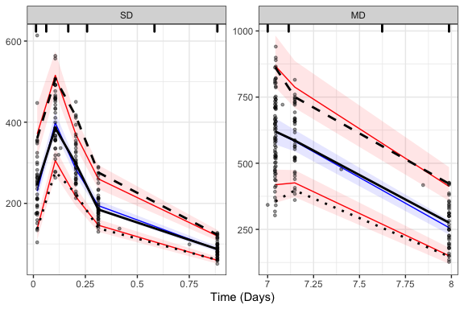

```r
vpc <-
  df.nm.obs %>%
  bind_cols(df.tad.pred) %>%
  mutate(PHASE = factor(PHASE, levels = c("SD", "MD"))) %>%
  observed(x=TIME, y=DV) %>%
  simulated(df.mrgsim.vpc, y=DV) %>%
  stratify(~PHASE) %>%
  # binning(bin = NTIM) %>%
  binning(bin = "breaks", breaks = c(0, 1, 4, 5, 12, 24, 171, 185, 200)) %>%
  vpcstats()

plot(vpc) +
  xgx_scale_x_time_units(units_dataset = time_units_dataset,
                         units_plot    = time_units_plot,
                         breaks = (0:40) * 6)
```

## VPC with TAD

We can use time after dose (TAD) calculated in `mrgsim()` and use that for VPC plot, even if you don’t have TAD in your original dataset

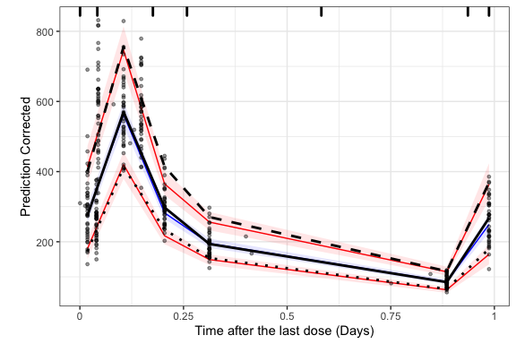

```r
vpc <-
  df.nm.obs %>%
  bind_cols(df.tad.pred) %>%
  mutate(PHASE = factor(PHASE, levels = c("SD", "MD"))) %>%
  observed(x=tad, y=DV) %>%
  simulated(df.mrgsim.vpc, y=DV) %>%
  binning(bin = "breaks", breaks = c(0, 1, 4, 5, 12, 22, 30)) %>%
  predcorrect(pred=PRED) %>%
  vpcstats()

plot(vpc) +
  xgx_scale_x_time_units(units_dataset = time_units_dataset,
                         units_plot    = time_units_plot,
                         breaks = (0:40) * 6) +
  labs(x = "Time after the last dose (Days)")
```